# prophetの変化点

UPDATE: 2021-09-15 00:09:05

# 1 はじめに

ここでは、下記のドキュメントを参考に、`prophet`パッケージの基本的な使い方をおさらいすることを目的としています。ゆくゆくは外部予測変数を追加したモデルやクロスバリデーション、パラメタチューニングなどなど、モデルを発展させながら使用方法をまとめていきます。

- [Prophet | Forecasting at scale](https://facebook.github.io/prophet/docs/quick_start.html#r-api)

モデルの数理部分は下記の`prophet`に関する論文やブログ記事を参照願います。非常にわかりやすいです。

- [Forecasting at scale](https://peerj.com/preprints/3190/)
- [Prophet入門【理論編】Facebookの時系列予測ツール](https://www.slideshare.net/hoxo_m/prophetfacebook)
- [Prophetのモデル式を1から理解する](https://devblog.thebase.in/entry/2019/12/20/110000_1)
- [fb Prophetの解剖で学ぶベイズ時系列モデリング](https://ill-identified.hatenablog.com/entry/2018/05/28/020224)

# 2 ライブラリと関数の読み込み

```r
library(prophet)
library(tidyverse)
library(patchwork)

head_tail <- function(data, n = 5){
  stopifnot(is.data.frame(data))
  head(data, n = n) %>% print()
  cat(paste(rep("-", 100), collapse = ""), "\n")
  tail(data, n = n) %>% print()
}
```

# 3 prophetの変化点

Prophetではどのように変化点を検知しているのか、今回はその点について見ていきます。デフォルト設定では、自動的に変化点を検知するようになっていますが、データに過学習しているとき、変化を捉えられていないときなど、新製品の発売日やイベントなどの既知の日付を使用して設定することで変化点を調整することが可能です。

$$g(t) = \frac{C_{t}}{ 1 + exp(-(k + \boldsymbol{a}(t) \cdot \boldsymbol{\delta^{ \mathrm{T}}}) (t - (m + \boldsymbol{a}(t) \cdot \boldsymbol{\gamma^{ \mathrm{T}}}))}$$

論文で説明されている内容を読むと、Prophetの変化点の自動検知は、大量の潜在的な変化点を可能な範囲で検知することから始まり、上記の式の変化率$\delta_{j}$に、スパース事前分布(ラプラス分布)を設定することで行われると説明されています。数年の時系列データであれば、1か月に1回程度で変化点を検知するとも書かれています。

$$\delta_{j} \sim Laplace(0, \tau)$$

パラメタ$\tau$ を調整することで、モデルの柔軟性を直接制御できるようになります。ラプラス分布は事前分布を用いることで、L1正則化と同様に機能し、パラメタ$\delta$が0になるように制約がかかります。これはラプラス分布を可視化するとわかりよいので、ラプラス分布を可視化してみます。ラプラス分布は$\mu$と$\tau$をパラメタに持ちます($\tau$は$\sigma$と表記されていたりします)。

$$f(x | \mu, \tau) = \frac{1}{2 \tau} exp\left(- \frac{ |x - \mu| }{ \tau } \right)$$

Rには、デフォルトでは関数が用意されていないので、確率密度関数を書いて可視化することにします。

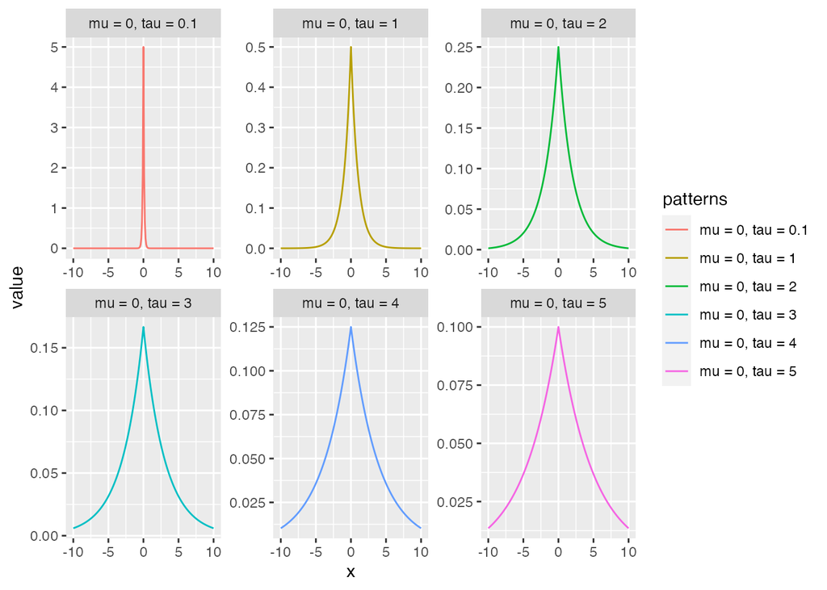

```r
drlaplace <- function(x, mu, tau){
  f <- 1/(2 * tau) * exp(-1 * (abs(x - mu)) / tau)
  return(f)
}

x <- seq(-10, 10, 0.1)
mu <- 0
tau <- c(0.1, 1:5)

pattern <- paste0('mu = ', mu, ', tau = ', tau)
df_plt <- tibble::tibble(x)
for (i in 1:length(tau)) {
  y <- drlaplace(x, mu, tau[[i]])
  df_plt <- cbind(df_plt, y)
}
names(df_plt) <- c('x', pattern)

df_plt %>%
  tidyr::pivot_longer(cols = -x, names_to = 'patterns') %>%
  dplyr::arrange(patterns, x) %>%
  ggplot(., aes(x, value, col = patterns, fill = patterns)) +
  geom_line() +
  facet_wrap( ~ patterns, scales = "free")
```

$\tau$が小さくなるほど、ほとんど0しか返さない確率密度関数であるため、それがスパースな分布と呼ばれる所以になっています。つまり、Prophetでは多めに潜在的な変化を検出するものの、変化率$\delta_{j}$にラプラス分布を設定していると、多くの変化点の変更率$\delta_{j}$はほとんど0になることが期待されます。

`Prophet()`では、`changepoint_prior_scale`で設定することができます。ドキュメントにも記載されていますが、値を大きくすると、多くの変化点が許容され、値が小さいと変化点が少なくなります。

# 4 Prophetの変化点自動検知

デフォルト設定でProphetの変化点の自動検知機能を動かしていきます。ドキュメントで使用されているWikipediaのページビューデータの期間を2年分に絞って動かしていきます。

```r
# Githubのprophetのリポジトリからサンプルデータをインポート
base_url <- 'https://raw.githubusercontent.com/facebook/prophet/master/examples/'
data_path <- paste0(base_url, 'example_wp_log_peyton_manning.csv')
df <- readr::read_csv(data_path) %>%
  dplyr::filter(ds >= "2011-01-01" & ds <= "2012-12-31")

# 先頭と末尾のデータを表示
head_tail(df, n = 5)
```

```
## # A tibble: 5 × 2
##   ds             y
##   <date>     <dbl>
## 1 2011-01-01  9.01
## 2 2011-01-02  9.40
## 3 2011-01-03  9.99
## 4 2011-01-04  9.06
## 5 2011-01-05  8.97
## ----------------------------------------------------------------------------------------------------
## # A tibble: 5 × 2
##   ds             y
##   <date>     <dbl>
## 1 2012-12-27  8.97
## 2 2012-12-28  8.68
## 3 2012-12-29  8.53
## 4 2012-12-30  9.49
## 5 2012-12-31 10.1
```

`changepoint_prior_scale`を変化させながら複数のモデルを構築するとわかり良いですが、`changepoint_prior_scale`が大きくなるにつれて(ラプラス分布の裾が広がる)、多くの変化点が許容され、値が小さくなるにつれて(ラプラス分布の裾が狭くなる)、変化点が少なくなります。変化点は`add_changepoints_to_plot()`を利用することで可視化できます。

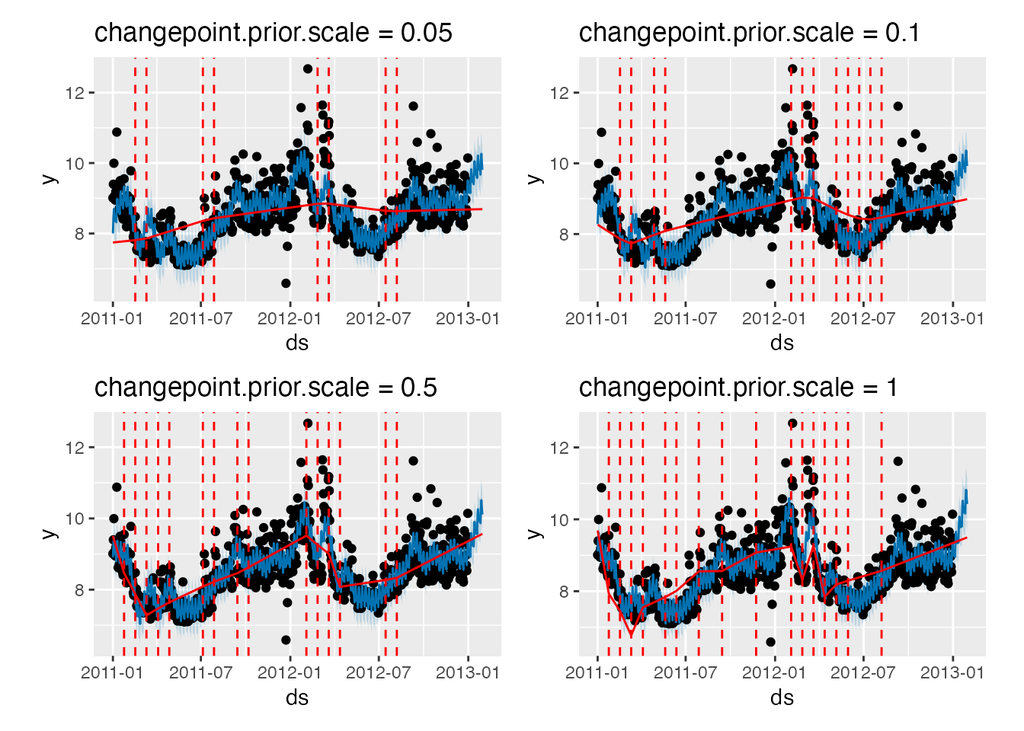

```r
# changepoint_prior_scaleを変化させてモデルを作成
scale_vec <- c(0.05, 0.1, 0.5, 1.0)
n_vec <- length(scale_vec)
plt_list <- vector(mode = "list", length = n_vec)

for (i in 1:n_vec) {
  m <- prophet(df = df, changepoint.prior.scale = scale_vec[[i]])
  future_df <- make_future_dataframe(m, periods = 30)
  forecast_df <- predict(m, future_df)
  plt_title <- paste0("changepoint.prior.scale = ", scale_vec[[i]])
  plt_list[[i]] <- plot(m, forecast_df) + add_changepoints_to_plot(m) +
    labs(title = plt_title)
}


plt_list[[1]] + plt_list[[2]] + plt_list[[3]] + plt_list[[4]]
```